# Fundamentals of Python

# 4 | NumPy Arrays

Arrays are n-dimensional objects (like a table) where multiple values can stored.

Base Python does not have a built-in data structure to handle arrays (the closest is a list) so we need to load a Python library called `NumPy`. If we are using a desktop version of Python then we will need to install the library from the terminal using `PIP` (note that this is not necessary in online IDEs such as Jupyter Notebook):

```r
pip install numpy
```

We can then tell Python to use this library at the beginning of our code using the `import` keyword:

```r
import numpy
```

Since we will be referring to `numpy` objects a lot, it makes sense to create an alias `np` which we can use instead:

```r
import numpy as np
```

Now we can create a sample array. Each row of an array is contained within a set of square brackets `[...]` and we create a new row with a comma `,`. The whole array is then contained within an outer set of square brackets `[...]`:

```r
import numpy as np

myarray = np.array([[1, 2, 3],
                    [4, 5, 6]])

print(myarray)
```

If we wish to create an array with more than two dimensions, then we can do so by creating another 2D array (as above), separated with a comma `,` and then contained within an outer set of square brackets `[...]`:

```r
import numpy as np

myarray = np.array([[[1, 2, 3], [4, 5, 6]],
                    [[7, 8, 9], [10, 11, 12]]])

print(myarray)
```

Each new pair of square brackets `[...]` represents a new dimension within the array. We can verify the number of dimensions or the shape of a `numpy` array with the `.ndim` and the `.shape` methods:

```r
import numpy as np

myarray = np.array([[[1, 2, 3], [4, 5, 6]],
                    [[7, 8, 9], [10, 11, 12]]])

print(myarray.ndim, myarray.shape)
```

Alternatively, we can start with a list of values which we then reshape into a NumPy array using the `.reshape(...)` method:

```r
import numpy as np

mylist = range(1, 13)

myarray = np.array(mylist)

print(myarray) #1D

myarray = myarray.reshape(2, 2, 3) #array with two levels, containing two rows and three columns

print(myarray) #3D
```

A common way of creating empty arrays is to start with an array filled with $0$ using `np.zeros(...)`. We can then use indexing to change specific elements of the array later:

```r
import numpy as np

myarray = np.zeros((3, 3, 3)) #create an array with three levels, three rows and three columns

print(myarray)
```

To select the index of specific elements in a NumPy array, we use a similar method using square brackets `[...]` as seen with Python lists. The difference is that we use multiple numbers separated by a comma to select each dimension of the array. The outermost dimension is put at the start `[outermost, ..., innermost]`:

```r
import numpy as np

myarray = np.array(range(1, 13)).reshape(2, 2, 3)
print(myarray)

x = myarray[1, 0, 2] #remember that Python indexing starts from 0... this would be the element in the second level of the first row of the third column
print(x)
```

To access an array element from the end, we use a negative `-` in front of the corresponding index:

```r
import numpy as np

myarray = np.array([[1, 2, 3, 4, 5],
                    [6, 7, 8, 9, 10]])

x = myarray[1, -2] #remember that Python indexing starts from 0... this is the element in the second row and the second last column
print(x)
```

Array slicing is where we access multiple elements at once. A slice uses a colon `:` between the start and end of a slice `start:end`. **Remember:** Python does not include the upper limit of this slice:

```r
import numpy as np

myarray = np.array([[1, 2, 3, 4, 5],
                    [6, 7, 8, 9, 10]])

x = myarray[1, 2:5] #remember that Python indexing starts from 0... these are the elements in the second row and the third to fifth columns
print(x)
```

We can also define a step to our slice `start:end:step`:

```r
import numpy as np

myarray = np.array([[1, 2, 3, 4, 5],
                    [6, 7, 8, 9, 10]])

x = myarray[1, 1:5:2] #remember that Python indexing starts from 0... these are the elements in the second row and alternate columns starting from column 2
print(x)
```

If no values are passed to the slice, Python will extract *all* elements of that dimension:

```r
import numpy as np

myarray = np.array([[1, 2, 3, 4, 5],
                    [6, 7, 8, 9, 10]])

x = myarray[1, :] #extract all elements in the second row
print(x)
```

We can update values in our array in the usual way:

```r
import numpy as np

myarray = np.zeros((3, 3, 3)) #create an array with three rows, three columns which are stacked three high

myarray[0, :, :] = 1 #update all elements in the first level with 1

myarray[1, :,2] = 2 #update all elements in the second level and third column with 2

myarray[2, ::2, 1] = 3 #update all elements in the third level and the alternate rows of the second column with 3

print(myarray)
```

To join arrays together we can use the `np.stack(...)` method which accepts a tuple of arrays to combine:

```r
import numpy as np

array1 = np.zeros((3, 3))
array2 = np.ones((3, 3))

myarray = np.stack((array1, array2), axis = 0)
print(myarray)
```

The `axis` dictates which dimension to stack in:

Axis

Description

Visualisation

`axis = 0`

By level

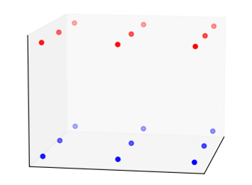

`axis = 1`

By row

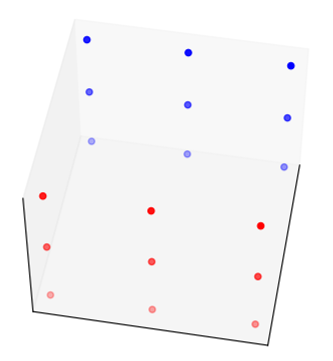

`axis = 2`

By column

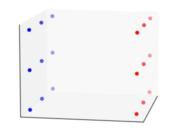

### Problem 12

> 1. Create a NumPy array named `x` which contains the even numbers between $2$ and $36$ (inclusive). The array should be 3 levels each consisting of 3 rows and 2 columns.
> 2. Create another NumPy array named `y` which contains the numbers `[100, 200, 300, 400, 500, 600]`. The array should be a single level consisting of 3 rows and 2 columns.
> 3. Create a new NumPy array named `z` which stacks `y` on top of `x` (by level).
> 4. Write a for loop which prints the elements of `z` in a list which is sorted from largest to smallest.

**Solutions**

```r
import numpy as np

#Q1
x = np.array(range(2, 37, 2)).reshape(3, 3, 2)
print(x)

#Q2
y = np.array([[100, 200],
              [300, 400],
              [500, 600]]).reshape(1, 3, 2)
print(y)

#Q3
z = np.vstack((x, y))
print(z)

#Q4
elem = []
for i in z: #each level
    for j in i: #each row
        for k in j: #each column
            elem.append(k)

elem.sort(reverse = True)
print(elem)
```

# 5 | Pandas

Pandas is a Python library which is used for processing and analysing data sets. It stems from “**P**ython **an**alysis of **da**ta **s**ets”.

Similar to NumPy, we need to install the Python library. If we are using a desktop version we will need to use `PIP` from the terminal first, but we do not need to do this step in online IDEs such as Jupyter Notebook:

```r
pip install pandas
```

We then import this library at the start of our Python code:

```r
import pandas
```

We can create an alias for this to make it quicker to refer to:

```r
import pandas as pd
```

Start by importing a demonstration data set which can be found in the [Moodle Materials](https://moodle.essex.ac.uk/pluginfile.php/2495377/mod_folder/content/0/CarData.csv?forcedownload=1). Source the file and read it in to Python.

If using Jupyter Notebook, we can upload this file directly into our project:

[figure not shown]

Upload the file into our project

We then load this file into Python using the `.read_csv(...)` method:

```r
import pandas as pd

data = pd.read_csv("CarData.csv")
```

Rather than printing the entire data set, we can just see the first five rows with the `.head()` method to make sure that the file has loaded correctly:

```r
import pandas as pd

data = pd.read_csv("CarData.csv")

data.head()
```

To extract specific **columns**, we can use a similar indexing technique to Python lists with square brackets `[...]`. Here, we pass a list with the names of the desired columns to keep:

```r
import pandas as pd

data = pd.read_csv("CarData.csv")

mydata = data[["Manufacturer", "Engine", "Weight"]] #select these columns
mydata.head()
```

```r
import pandas as pd

data = pd.read_csv("CarData.csv")

mydata = data.iloc[[0, 2, 5, 6]] #select these rows from list
mydata
```

```r
import pandas as pd

data = pd.read_csv("CarData.csv")

mydata = data.loc[[0, 2, 5, 6], ["Manufacturer", "Engine", "Weight"]] #select these rows and these columns
mydata
```

If we use the `.iloc[...]` method, then we can extract rows and columns by numbers (integers):

```r
import pandas as pd

data = pd.read_csv("CarData.csv")

mydata = data.iloc[[0, 2, 5, 6], [0, 3, 6]] #select these rows and these columns
mydata
```

```r
import pandas as pd

data = pd.read_csv("CarData.csv")

mydata = data.set_index("Manufacturer") #reindex by manufacturer
mydata
```

This allows us to extract rows according to this new index:

```r
import pandas as pd

data = pd.read_csv("CarData.csv")

mydata = data.set_index("Manufacturer")
mydata.loc["Fusion"] #since reindexed, extract rows with the Fusion manufacturer
```

We can search for all instances where a value occurs within a particular column:

```r
import pandas as pd

data = pd.read_csv("CarData.csv")

rownumber = data["Range"] > 320 #find vehicles with a range over 320
rownumber
```

This means that we can then extract these rows using the `.loc[...]` method:

```r
import pandas as pd

data = pd.read_csv("CarData.csv")

rownumber = data["Range"] > 320
mydata = data.loc[rownumber] #extract only vehicles with a range over 320
mydata
```

```r
import pandas as pd

data = pd.read_csv("CarData.csv")

mydata = data.dropna() #remove any rows which contain missing values
mydata
```

Alternatively, we could fill these missing values with a value using the `.fillna(...)` method:

```r
import pandas as pd

data = pd.read_csv("CarData.csv")

mydata = data.fillna(0) #replace missing values with a 0
mydata
```

If we only wanted to fill a specific column’s missing values, then we would use the column indexing method. Note that we will need to overwrite the existing stored data set in this method so we use `inplace = True` as one of the arguments:

```r
import pandas as pd

data = pd.read_csv("CarData.csv")

data["Engine"].fillna("battery", inplace=True) #replace missing values in the engine column with a string
data["Transmission"].fillna(False, inplace = True) #replace missing values in the transmission column with a Boolean
data["Gears"].fillna(0, inplace=True) #replace missing values in the gears column with a value
data
```

Alternatively, we could choose to remove the rows which have missing values with the `.dropna()` method. Again, if we want to overwrite the existing data set, we will add `inplace = True`:

```r
import pandas as pd

data = pd.read_csv("CarData.csv")

data.dropna(inplace = True) #remove any rows with missing values
data
```

Note that this method will cause Python to remove rows which have missing values **anywhere**. If we just wanted to drop rows which had missing values in specific columns, we could use the option `subset = [...]` where this accepts a list of columns:

```r
import pandas as pd

data = pd.read_csv("CarData.csv")

data.dropna(subset = ["Transmission"], inplace = True) #remove rows which have missing values in the transmission column
data
```

If we wanted to add a new column to the data, we can simply use indexing with the name of our new column and the list of values to include:

```r
import pandas as pd

data = pd.read_csv("CarData.csv")

data["Power to Weight"] = data["Horsepower"] / data["Weight"] #divide elements in horsepower columns by elements weight columns and store in a new column
data
```

Finally, we can merge two data sets together with the `pd.concat(...)` method:

```r
import pandas as pd

data = pd.read_csv("CarData.csv")

# Create two new data frames as a subset of data
Fusion_Rows = data["Manufacturer"] == "Fusion"
Horizon_Rows = data["Manufacturer"] == "Horizon"

df1 = data[Fusion_Rows]
df2 = data[Horizon_Rows]

# Concatenate along rows
mydata = pd.concat([df1, df2])
mydata
```

```r
import pandas as pd

data = pd.read_csv("CarData.csv")

# Create two new data frames as a subset of data
Fusion_Rows = data["Manufacturer"] == "Fusion"
Horizon_Rows = data["Manufacturer"] == "Horizon"

df1 = data[Fusion_Rows]
df2 = data[Horizon_Rows]

# Concatenate along rows
mydata = pd.concat([df1, df2], ignore_index = True)
mydata
```

### Problem 13

> A shop keeps a record of goods sold. At the end of each quarter (3 months), it compiles the sales report. These reports can be found here:
> - [Q1_2024.csv - Quarter 1 of 2024](https://moodle.essex.ac.uk/pluginfile.php/2495377/mod_folder/content/0/Pandas%20Question%20Data%20Sets/Q1_2024.csv?forcedownload=1)
> - [Q2_2024.csv - Quarter 2 of 2024](https://moodle.essex.ac.uk/pluginfile.php/2495377/mod_folder/content/0/Pandas%20Question%20Data%20Sets/Q2_2024.csv?forcedownload=1)
> - [Q3_2024.csv - Quarter 3 of 2024](https://moodle.essex.ac.uk/pluginfile.php/2495377/mod_folder/content/0/Pandas%20Question%20Data%20Sets/Q3_2024.csv?forcedownload=1)
> - [Q4_2024.csv - Quarter 4 of 2024](https://moodle.essex.ac.uk/pluginfile.php/2495377/mod_folder/content/0/Pandas%20Question%20Data%20Sets/Q4_2024.csv?forcedownload=1)

> Download the four data files corresponding to sales reports from each quarter and load these into Python using Pandas. Then attempt the following:
> 1. Combine the data files into a single data frame corresponding to all the sales data for 2024.
> 2. Add a new column called `Transaction amount` which corresponds to the amount taken in each transaction. This is achieved by taking the item sold and multiplying by the cost per item for every order.
> 3. Create a new column called `Month` corresponding to the name of the month when that item was sold. **Hint:** the `Date` column has dates formatted `day/month/year`. You could use a substring command to extract the digits of the month and then convert this to a named month. For example, `01 = Jan`
> 4. Create a data frame called `profits` which summarises the total number of items sold and the total value of the transactions taken for each month.
> 5. Write the `profits` dataframe to a `.csv` file.

**Solutions**

```r
import pandas as pd

#Q1
Q1 = pd.read_csv("Q1_2024.csv")
Q2 = pd.read_csv("Q2_2024.csv")
Q3 = pd.read_csv("Q3_2024.csv")
Q4 = pd.read_csv("Q4_2024.csv")

data = pd.concat([Q1, Q2, Q3, Q4], ignore_index = True) #concatenate the four datasets

#Q2
data["Transaction amount"] = data["Quantity"] * data["Cost per item"] #new column

#Q3
data["Month"] = data["Date"].str[3:5] #get month number

#Create a dictionary of months
month_map = {"01": "Jan",
             "02": "Feb",
             "03": "Mar",
             "04": "Apr",
             "05": "May",
             "06": "Jun",
             "07": "Jul",
             "08": "Aug",
             "09": "Sep",
             "10": "Oct",
             "11": "Nov",
             "12": "Dec"}

data["Month"] = data["Month"].map(month_map) #map the element in Months to the correct dictionary value

#Q4
temp_transactiondata = []
temp_profitsdata = []
for i in month_map.values():

    #find the data from that month and store in a temporary dataframe
    rows = data["Month"] == i
    temp_dataframe = data[rows]

    #calculate the sum of the data from that month
    monthlytransactions = temp_dataframe["Quantity"].sum()
    monthlyprofits = temp_dataframe["Transaction amount"].sum().round(2)

    #append this to a list for use later
    temp_transactiondata.append(monthlytransactions)
    temp_profitsdata.append(monthlyprofits)

#Create a new dataframe
profits = pd.DataFrame() #empty dataframe
profits["Month"] = month_map.values() #create a column
profits["No. of items sold"] = temp_transactiondata #create a column
profits["Value of transactions"] = temp_profitsdata #create a column

#Q5
profits.to_csv("ProfitsData.csv", index=False)
```